# Prueba 2 - Informe

Introducción a Ciencia de Datos - UCAB Abril 2022

Ana Gabriela Ibarra

Ana Leticia Ibarra

2022-07-15

## Introducción

Es conocido que el análisis de datos es una herramienta crucial para el proceso de toma de decisiones. Estas decisiones no se limitan al ámbito empresarial o económico, sino también se extienden al campo de salud.

Un área de la salud que consideramos importante analizar es la salud sexual y reproductiva, en vista del creciente interés debido a la reciente decisión de la Corte Suprema de los Estados Unidos (anulación de [Roe v. Wade](https://www.guttmacher.org/abortion-rights-supreme-court)).

Debido a la importancia actual de la salud sexual y derechos reproductivos, consideramos que orientar este proyecto hacia este tema podría ilustrar la realidad que se vive a nivel regional en torno a la situación de embarazos deseados y no deseados, mujeres que desean evitar el embarazo, así como también al aborto.

## Objetivo

Realizar un análisis exploratorio de datos mediante el procesamiento y visualización de los mismos, con el fin de determinar si el aborto y los embarazos no deseados son comunes a nivel continental y si existen diferencias en las tasas de mujeres que desean evitar el embarazo entre regiones urbanas y rurales.

## Fuentes de datos

En esta ocasión estaremos usando 3 fuentes de datos diferentes que se relacionan entre sí, a continuación las listaremos y las describiremos brevemente:

- Tasa de abortos

```r
dirty_abrate <- read_excel("datasets/ds-abrate.xlsx")

dirty_abrate[dirty_abrate == 'u'] <- NA

# Subset de países con valores NA
na_ab_rate <- dirty_abrate[!complete.cases(dirty_abrate),]
na_ab_rate <- na_ab_rate[-(26:28),]
```

```
- La base de datos tiene por país para el período 2015-2019 el porcentaje promedio de embarazos que terminan en aborto, tanto los deseados como no deseados; promedio anual de abortos en mujeres entre 15-49 años; promedio anual de aborto por cada 1000 mujeres entre 15-49 años.
-   Número de observaciones: 178
-   Cantidad de variables: 5
-   Valores faltantes: 25
```

```r
summary(dirty_abrate)
```

```
##    Country
##  Length:178
##  Class :character
##  Mode  :character
##  Average annual % of all pregnancies ending in abortion, 2015-2019
##  Length:178
##  Class :character
##  Mode  :character
##  Average annual % of unintended pregnancies ending in abortion, 2015-2019
##  Length:178
##  Class :character
##  Mode  :character
##  Average annual no. of abortions among women aged 15–49, 2015-2019
##  Length:178
##  Class :character
##  Mode  :character
##  Average annual no. of abortions per 1,000 women aged 15–49, 2015-2019
##  Length:178
##  Class :character
##  Mode  :character
```

- Embarazos deseados vs. no deseados

```r
dirty_wntdprg <- read_excel("datasets/ds-wntdprg.xlsx")

dirty_wntdprg[dirty_wntdprg == 'u'] <- NA

# Subset de países con valores NA
na_wntd_prg <- dirty_wntdprg[!complete.cases(dirty_wntdprg),]
na_wntd_prg <- na_wntd_prg[-(44:46),]
```

```
-   La base de datos tiene por país para 2019 diversas variables para la tasa de mujeres que desean o no evitar el embarazo de acuerdo al área, edad, percentil de ingresos y estado civil.
-   Cantidad de observaciones: 178
-   Cantidad de variables: 19
-   Valores faltantes: 43. Sabemos que es una lista bastante larga, pero hay países cuyos datos no son accesibles.
```

```r
summary(dirty_wntdprg)
```

```
##    Country
##  Length:178
##  Class :character
##  Mode  :character
##  % of rural women aged 15–49 not wanting to avoid pregnancy, 2019 [1]
##  Length:178
##  Class :character
##  Mode  :character
##  % of rural women aged 15–49 who want to avoid pregnancy, 2019 [2]
##  Length:178
##  Class :character
##  Mode  :character
##  % of urban women aged 15–49 not wanting to avoid pregnancy, 2019 [1]
##  Length:178
##  Class :character
##  Mode  :character
##  % of urban women aged 15–49 who want to avoid pregnancy, 2019 [2]
##  Length:178
##  Class :character
##  Mode  :character
##  % of women aged 15–19 not wanting to avoid pregnancy, 2019 [1]
##  Length:178
##  Class :character
##  Mode  :character
##  % of women aged 15–19 who want to avoid pregnancy, 2019 [2]
##  Length:178
##  Class :character
##  Mode  :character
##  % of women aged 15–49 not wanting to avoid pregnancy, 2019 [1]
##  Length:178
##  Class :character
##  Mode  :character
##  % of women aged 15–49 who want to avoid pregnancy, 2019 [2]
##  Length:178
##  Class :character
##  Mode  :character
##  Among women aged 15–49 formerly in union, % not wanting to avoid pregnancy, 2019 [1]
##  Length:178
##  Class :character
##  Mode  :character
```

[output cut: 21 more lines]

```
##  Length:178
##  Class :character
##  Mode  :character
##  Among women aged 15–49 in union, % who want to avoid pregnancy, 2019 [2]
##  Length:178
##  Class :character
##  Mode  :character
##  Among women aged 15–49 never in union, % not wanting to avoid pregnancy, 2019 [1]
##  Length:178
##  Class :character
##  Mode  :character
##  Among women aged 15–49 never in union, % who want to avoid pregnancy, 2019 [2]
##  Length:178
##  Class :character
##  Mode  :character
```

- [Regiones](https://github.com/lukes/ISO-3166-Countries-with-Regional-Codes/blob/master/all/all.csv)

```r
regions <- read.csv("datasets/all.csv")
```

[output not shown]

```r
summary(regions)
```

```
##      name             alpha.2            alpha.3           country.code
##  Length:249         Length:249         Length:249         Min.   :  4.0
##  Class :character   Class :character   Class :character   1st Qu.:218.0
##  Mode  :character   Mode  :character   Mode  :character   Median :434.0
##                                                           Mean   :433.8
##                                                           3rd Qu.:652.0
##                                                           Max.   :894.0
##
##   iso_3166.2           region           sub.region        intermediate.region
##  Length:249         Length:249         Length:249         Length:249
##  Class :character   Class :character   Class :character   Class :character
##  Mode  :character   Mode  :character   Mode  :character   Mode  :character
##
##
##
##
##   region.code     sub.region.code  intermediate.region.code
##  Min.   :  2.00   Min.   : 15.00   Min.   :  5.00
##  1st Qu.:  9.00   1st Qu.: 53.75   1st Qu.: 11.00
##  Median : 19.00   Median :154.00   Median : 14.00
##  Mean   : 65.95   Mean   :179.87   Mean   : 31.72
##  3rd Qu.:142.00   3rd Qu.:202.00   3rd Qu.: 29.00
##  Max.   :150.00   Max.   :419.00   Max.   :830.00
##  NA's   :1        NA's   :1        NA's   :142
```

## Limpieza de datos

Uno de los retos que encontramos al hacer la limpieza de los datos fue intentar agrupar los datos por regiones. Para ello fue necesario estandarizar los nombres de los países en todas las bases de datos para posteriormente unir las bases de datos de tasa de aborto y embarazos con la de regiones mediante la columna país.

Adicionalmente, seleccionamos algunas de las variables de las bases de datos, ya que quisimos enfocar el estudio en las variables relacionadas a las áreas rurales y urbanas y percentiles de ingreso para embarazos y las tasas de aborto para embarazos no deseados.

## Base de datos a utilizar

Finalmente, luego de la limpieza de datos obtuvimos los siguientes datasets:

```r
ab_data <- read.csv("datasets/ab_data.csv")
preg_data <- read.csv("datasets/preg_data.csv")
```

```r
summary(ab_data)
```

```
##    Country          avg_perc_preg_eia avg_perc_uw_preg_eia    region
##  Length:150         Min.   : 5.00     Min.   :20.00        Length:150
##  Class :character   1st Qu.:15.00     1st Qu.:32.00        Class :character
##  Mode  :character   Median :19.50     Median :43.00        Mode  :character
##                     Mean   :21.27     Mean   :46.29
##                     3rd Qu.:26.00     3rd Qu.:58.00
##                     Max.   :51.00     Max.   :86.00
```

```r
summary(preg_data)
```

```
##    Country          perc_rural_w_nwap perc_rural_w_wap perc_urban_w_nwap
##  Length:132         Min.   :20.00     Min.   :17.00    Min.   :23.00
##  Class :character   1st Qu.:41.75     1st Qu.:39.00    1st Qu.:41.00
##  Mode  :character   Median :51.00     Median :49.00    Median :50.50
##                     Mean   :51.71     Mean   :48.29    Mean   :50.21
##                     3rd Qu.:61.00     3rd Qu.:58.25    3rd Qu.:59.00
##                     Max.   :83.00     Max.   :80.00    Max.   :72.00
##  perc_urban_w_wap perc_poor_w_nwap perc_poor_w_wap perc_rich_w_nwap
##  Min.   :28.00    Min.   :23.00    Min.   :22.00   Min.   :21.00
##  1st Qu.:41.00    1st Qu.:42.00    1st Qu.:39.00   1st Qu.:42.75
##  Median :49.50    Median :52.00    Median :48.00   Median :50.00
##  Mean   :49.79    Mean   :51.76    Mean   :48.24   Mean   :51.04
##  3rd Qu.:59.00    3rd Qu.:61.00    3rd Qu.:58.00   3rd Qu.:62.00
##  Max.   :77.00    Max.   :78.00    Max.   :77.00   Max.   :76.00
##  perc_rich_w_wap    region
##  Min.   :24.00   Length:132
##  1st Qu.:38.00   Class :character
##  Median :50.00   Mode  :character
##  Mean   :48.96
##  3rd Qu.:57.25
##  Max.   :79.00
```

## Visualización de datos

A pesar de que los embarazos no deseados y el aborto tengan poca visibilidad en las sociedades, son un problema común y relevante a nivel mundial que ocurren independientemente de variables socioeconómicas y geográficas.

Como se puede observar en el gráfico 1, la tasa de embarazos que terminan en aborto son mayores al 10% de la población femenina en todas las regiones continentales. Destacan los continentes americano y asiático debido a las elevadas tasas de más de 20%. Sin embargo, debe tomarse en cuenta factores que podrían explicar este resultado, como la densidad poblacional.

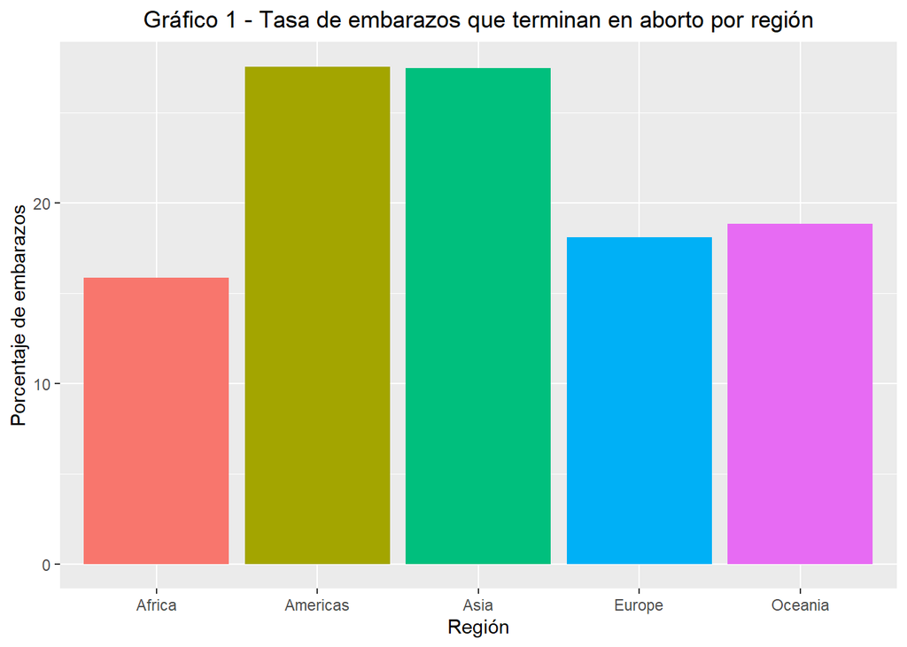

Por su parte, al profundizar en la data de embarazos que terminan en aborto, se puede observar que los embarazos no deseados que terminan en aborto suponen una proporción significativa para los continentes. Destaca la región asiática con más de 60% de los embarazos no deseados que terminan en aborto.

Resulta interesante ver que, a diferencia de la gráfica 1, en el caso de la región americana los embarazos no deseados que terminan en aborto no están al mismo nivel que la región asiática.

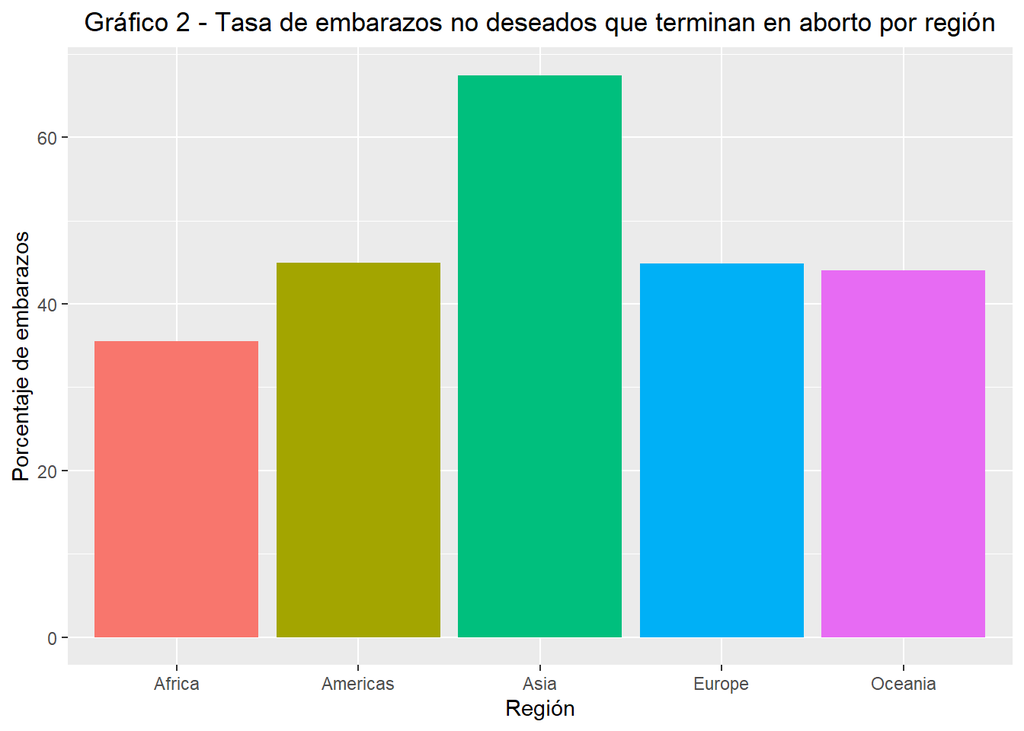

Al indagar sobre el caso de las mujeres que desean evitar el embarazo, resulta relevantehacer la distinción de acuerdo al área de procedencia de la mujer: rural o urbana.

En este caso, se puede observar que la mediana en las Americas es similar tanto para áreas urbanas como rurales, lo que difiere al caso europeo. En el caso de Asia existe un valor atípico, marcado por el punto fuera del diagrama de caja. Resulta interesante ver como en Oceanía existe menor variación de los datos, mientras que en el resto de las regiones continentales hay mayor nivel de variación intercuartílica entre áreas.

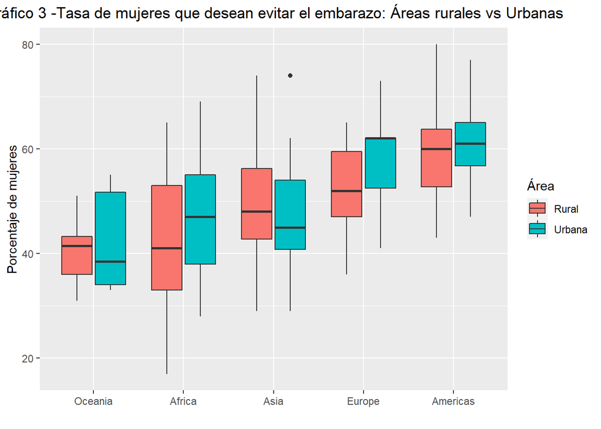

Adicionalmente, se puede realizar una distinción de la tasa de mujeres que desean evitar el embarazo de acuerdo al percentil de ingresos de la mujer: ingresos bajos o altos.

Tanto en la región americana como en la asiática resalta la existencia de valores atípicos que se encuentran fuera del diagrama de caja. En Europa, para la tasa de mujeres que desean evitar el embarazo, el tercer cuartil de ingresos bajos se encuentra casi al mismo nivel del primer cuartil para ingresos altos. Asimismo, se evidencia lo opuesto en Oceanía: para la tasa de mujeres que desean evitar el embarazo, el primer cuartil de ingresos bajos se encuentra casi al mismo nivel del cuarto cuartil para ingresos altos.

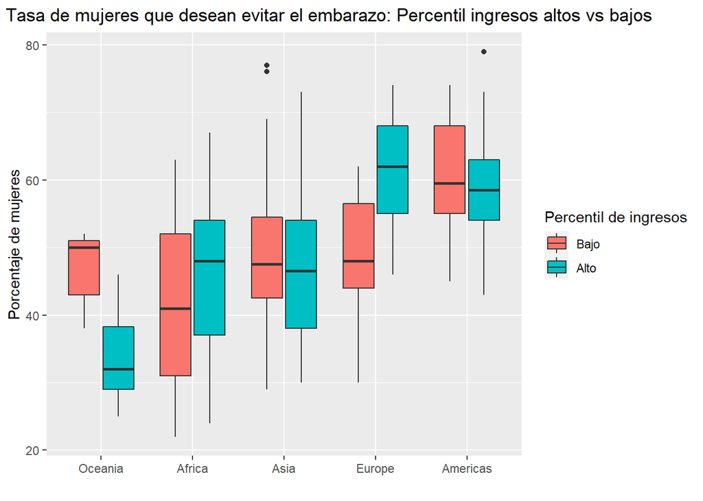

## Conclusiones

Tanto el embarazo no planificado como el aborto son experiencias compartidas por las mujeres a nivel mundial, sin importar el área de donde provengan, su percentil de ingresos o su región. El análisis y la visualización de los datos permite ilustrar estos números en gráficos y hacer del proceso de toma de decisiones algo inclusivo y equitativo. Para hacer esto sería ideal no sólo completar las observaciones incompletas, sino también estudiar los comportamientos a nivel mundial durante los últimos años.

Sin embargo, con las observaciones y variables analizadas podemos concluir que independientemente de factores socioeconómicos o geográficos los abortos y los embarazos no deseados ocurren. Es de suma importancia que se tengan en cuenta estos factores para sentar las bases y planificar programas y políticas para mejorar la atencion de la salud sexual y reproductiva.

## Enlaces de interés

- [Aborto inducido a nivel mundial](https://www.guttmacher.org/es/fact-sheet/aborto-inducido-nivel-mundial)
- [Repositorio Github del Proyecto](https://github.com/analetty/dsci-prueba2)
- [Importancia de desarrollar políticas mejor enfocadas](https://www.guttmacher.org/es/article/2022/05/nueva-evidencia-sobre-embarazo-no-planeado-y-aborto-en-150-paises-muestra-la)